# 6_9_Exercises_Review_Solved

## Exercise 1 True or False? Explain your answer:

1. Good forecast methods should have normally distributed residuals

```r
# False. Although many good forecasting methods produce normally distributed
# residuals this is not required to produce good forecasts. Other forecasting
# methods may use other distributions, it is just less common as they can be
# more difficult to work with.
```

2. A model with small residuals will give good forecasts

```r
# False. It is possible to produce a model with small residuals by making a
# highly complicated (overfitted) model that fits the data extremely well.
# This highly complicated model will often perform very poorly when forecasting new data.
```

3. The best measure of forecast accuracy is MAPE.

```r
# False. There is no single best measure of accuracy - often you would want to
# see a collection of accuracy measures as they can reveal different things about
# your residuals. MAPE in particular has some substantial disadvantages -
# extreme values can result when yt is close to zero, and it assumes that the
# unit being measured has a meaningful zero.
```

4. If your model doesn’t forecast well, you should make it more complicated

```r
# False. There are many reasons why a model may not forecast well, and making the
# model more complicated can make the forecasts worse. The model specified should
# capture structures that are evident in the data. Although adding terms that are
# unrelated to the structures found in the data will improve the model’s residuals,
# the forecasting performance of the model will not improve. Adding missing features
# relevant to the data (such as including a seasonal pattern that exists in the data)
# should improve forecast performance.
```

5. Always choose the model with the best forecast accuracy as measured on the test set

```r
# False. There are many measures of forecast accuracy, and the appropriate model is
# the one which is best suited to the forecasting task. For instance, you may be
# interested in choosing a model which forecasts well for predictions exactly one
# year ahead. In this case, using cross-validated accuracy could be a more
# useful approach to evaluating accuracy.
```

## Exercise 2

The dataset `aus_retail` contains retail data for different australian retail industries. Specifically the industries covered are:

```r
aus_retail %>% distinct(Industry)
```

```
# A tibble: 20 × 1
   Industry
   <chr>
 1 Cafes, restaurants and catering services
 2 Cafes, restaurants and takeaway food services
 3 Clothing retailing
 4 Clothing, footwear and personal accessory retailing
 5 Department stores
 6 Electrical and electronic goods retailing
 7 Food retailing
 8 Footwear and other personal accessory retailing
 9 Furniture, floor coverings, houseware and textile goods retailing
10 Hardware, building and garden supplies retailing
11 Household goods retailing
12 Liquor retailing
13 Newspaper and book retailing
14 Other recreational goods retailing
15 Other retailing
16 Other retailing n.e.c.
17 Other specialised food retailing
18 Pharmaceutical, cosmetic and toiletry goods retailing
19 Supermarket and grocery stores
20 Takeaway food services
```

We are interested in the industry *Takeaway food services*.

1. Compute the total turnover per month of all australian States combined. Plot the resulting series:

```r
aus_retail
```

```
# A tsibble: 64,532 x 5 [1M]
# Key:       State, Industry [152]
   State                        Industry                Serie…¹    Month Turno…²
   <chr>                        <chr>                   <chr>      <mth>   <dbl>
 1 Australian Capital Territory Cafes, restaurants and… A33498… 1982 Apr     4.4
 2 Australian Capital Territory Cafes, restaurants and… A33498… 1982 May     3.4
 3 Australian Capital Territory Cafes, restaurants and… A33498… 1982 Jun     3.6
 4 Australian Capital Territory Cafes, restaurants and… A33498… 1982 Jul     4
 5 Australian Capital Territory Cafes, restaurants and… A33498… 1982 Aug     3.6
 6 Australian Capital Territory Cafes, restaurants and… A33498… 1982 Sep     4.2
 7 Australian Capital Territory Cafes, restaurants and… A33498… 1982 Oct     4.8
 8 Australian Capital Territory Cafes, restaurants and… A33498… 1982 Nov     5.4
 9 Australian Capital Territory Cafes, restaurants and… A33498… 1982 Dec     6.9
10 Australian Capital Territory Cafes, restaurants and… A33498… 1983 Jan     3.8
# … with 64,522 more rows, and abbreviated variable names ¹`Series ID`,
#   ²Turnover
```

```r
aus_retail %>%
  filter(Industry == "Takeaway food services") %>%
  index_by(Month) %>%
  summarize(
    Turnover = sum(Turnover)
  )
```

```
# A tsibble: 441 x 2 [1M]
      Month Turnover
      <mth>    <dbl>
 1 1982 Apr     194.
 2 1982 May     194.
 3 1982 Jun     186.
 4 1982 Jul     190.
 5 1982 Aug     190.
 6 1982 Sep     195.
 7 1982 Oct     209
 8 1982 Nov     212.
 9 1982 Dec     238.
10 1983 Jan     225.
# … with 431 more rows
```

```
Plot variable not specified, automatically selected `.vars = Turnover`
```

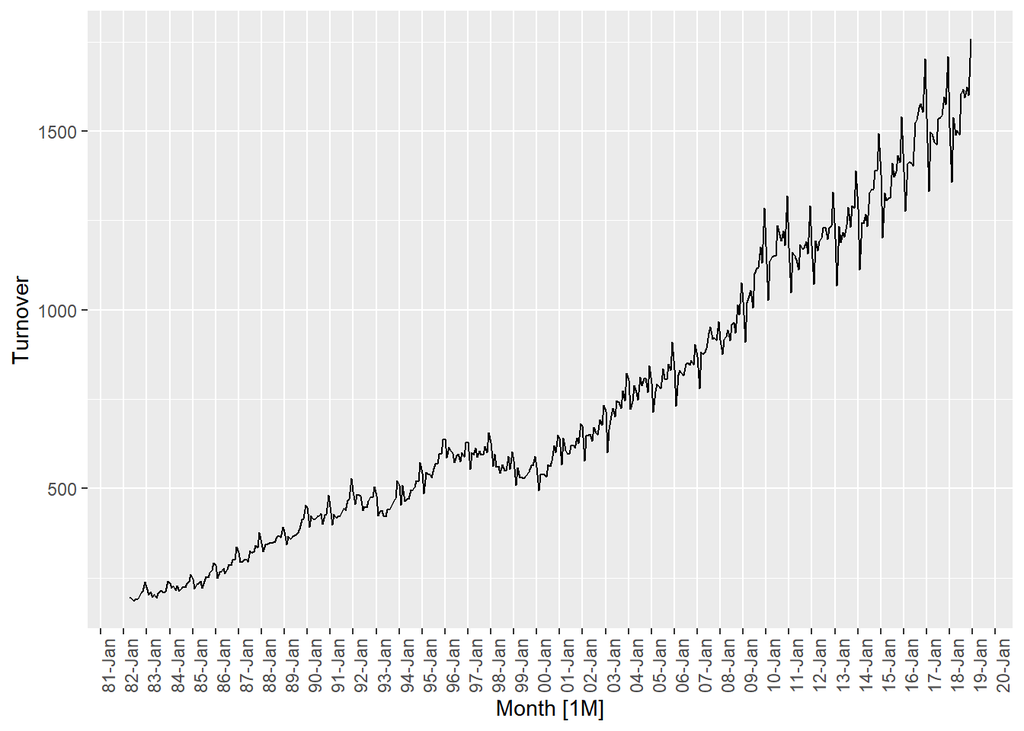

```r
takeaway <- aus_retail %>%
  filter(Industry == "Takeaway food services")

takeaway <- aus_retail %>%
  filter(Industry == "Takeaway food services") %>%
  summarise(Turnover = sum(Turnover))

autoplot(takeaway) +
scale_x_yearmonth(date_breaks = "1 year",
                  date_minor_breaks = "1 year",
                  date_labels = "%y-%b") +

# Flip x-labels by 90 degrees
theme(axis.text.x = element_text(angle = 90))
```

2. Create a training withholding the last four years as a test set

```r
test_years = 4
train <- takeaway %>%
  filter(Month <= max(Month) - test_years * 12)

# Check that the test dataset does indeed contain 4*12 years
nrow(takeaway) - nrow(train) == 4*12
```

```
[1] TRUE
```

3. Obtain the optimal value of lambda suggested for a box-cox transformation. Use the whole time-series (not only the training dataset). Create a timeplot showing the result of applying that box-cox transsformation as a well as a log transformation.

```r
lambda <- takeaway %>%
  features(Turnover, features = guerrero) %>%
  pull(lambda_guerrero)

lambda
```

```
[1] 0.04226665
```

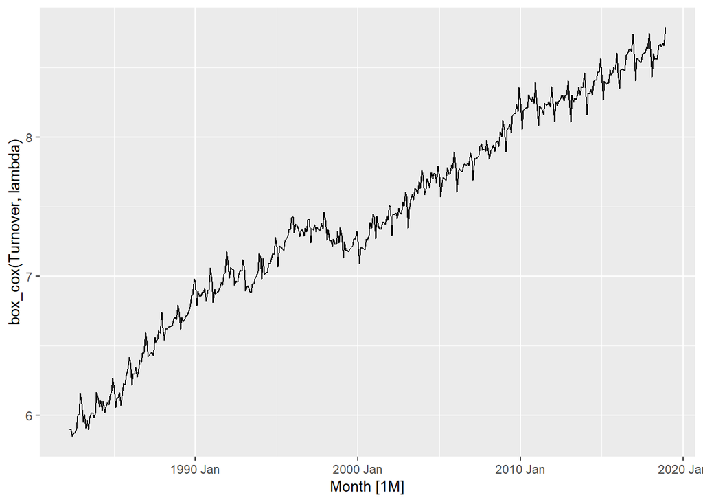

```r
takeaway %>% autoplot(box_cox(Turnover, lambda))
```

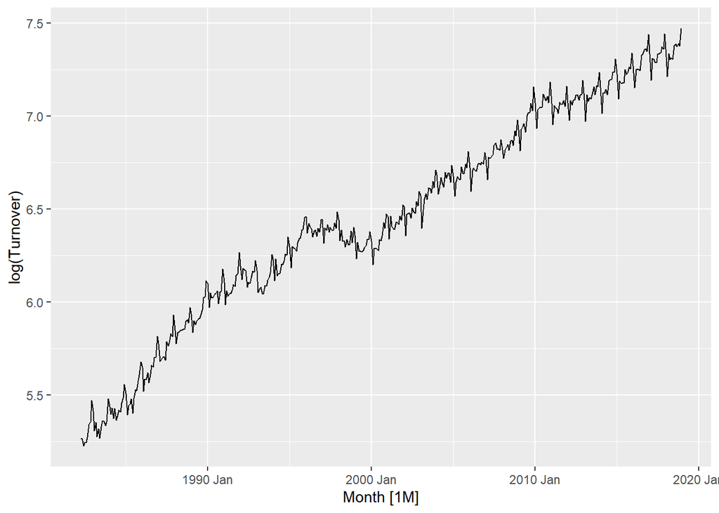

```r
takeaway %>% autoplot(log(Turnover))
```

Examining the transformed graphs does not reveal that any of the two transformations performs better than the other. What is more, graphically it appears as though the log transformation were a bit better at achieving an additive scheme (at evening out the changes of the variance of the seasonal component with the level of the series).

3. Fit the following models to the training dataset and forecast four years into the future with every model:
- `decomposition_model` applying an STL decomposition and a log transformation. Use a drift model for the seasonally adjusted component and a seas. naïve model for the seasonal component.
- `decomposition_model` applying an STL decomposition and a box-cox transformation with the value of lambda suggested by the guerrero feature.Use a drift model for the seasonally adjusted component and a seas. naïve model for the seasonal component.
- `decomposition_model` applyting an STL decomposition with no transformation (technically incorrect since data is multiplicative). Use a drift model for the seasonally adjusted component and a seas. naïve model for the seasonal component.
- `naive` model
- `mean` model
- `seasonal naive` model
- `drift` model
- `simple exponential smoothing` model

```r
train %>% model(STL(log(Turnover))) %>% components()
```

```
# A dable: 393 x 7 [1M]
# Key:     .model [1]
# :        log(Turnover) = trend + season_year + remainder
   .model                Month `log(Turnover)` trend season_y…¹ remain…² seaso…³
   <chr>                 <mth>           <dbl> <dbl>      <dbl>    <dbl>   <dbl>
 1 STL(log(Turnover)) 1982 Apr            5.27  5.28    -0.0345  0.0223     5.30
 2 STL(log(Turnover)) 1982 May            5.27  5.28    -0.0147 -0.00238    5.28
 3 STL(log(Turnover)) 1982 Jun            5.23  5.29    -0.0667  0.00371    5.29
 4 STL(log(Turnover)) 1982 Jul            5.24  5.30    -0.0261 -0.0259     5.27
 5 STL(log(Turnover)) 1982 Aug            5.25  5.30    -0.0126 -0.0397     5.26
 6 STL(log(Turnover)) 1982 Sep            5.27  5.31    -0.0153 -0.0176     5.29
 7 STL(log(Turnover)) 1982 Oct            5.34  5.31     0.0175  0.0119     5.32
 8 STL(log(Turnover)) 1982 Nov            5.36  5.32     0.0229  0.0178     5.34
 9 STL(log(Turnover)) 1982 Dec            5.47  5.32     0.114   0.0352     5.36
10 STL(log(Turnover)) 1983 Jan            5.41  5.33     0.0621  0.0236     5.35
# … with 383 more rows, and abbreviated variable names ¹season_year,
#   ²remainder, ³season_adjust
```

```r
fit <- train %>%
  model(
    decomp_log = decomposition_model(
                 # Specify decomposition scheme to be used
                 STL(log(Turnover)),
                 # Specify model for the seasonally adjusted component
                 RW(season_adjust ~ drift()),
                 # Specify model for the seasonal component (unnecessary since SNAIVE is default)
                 SNAIVE(season_year)
                 ),
    decomp_bc = decomposition_model(
                 # Specify decomposition scheme to be used
                 STL(box_cox(Turnover, lambda)),
                 # Specify model for the seasonally adjusted component
                 RW(season_adjust ~ drift()),
                 # Specify model for the seasonal component (unnecessary since SNAIVE is default)
                 SNAIVE(season_year)
                 ),
    decomp = decomposition_model(
                 # Specify decomposition scheme to be used
                 STL(Turnover),
                 # Specify model for the seasonally adjusted component
                 RW(season_adjust ~ drift()),
                 # Specify model for the seasonal component (unnecessary since SNAIVE is default)
                 SNAIVE(season_year)
                 ),
    naive = NAIVE(Turnover),
    drift = RW(Turnover ~ drift()),
    mean = MEAN(Turnover),
    snaive = SNAIVE(Turnover),
    SES = ETS(Turnover ~ error("A") + trend("N") + season("N"))
  )

fit
```

```
# A mable: 1 x 8
                 decomp_log                 decomp_bc                    decomp
                    <model>                   <model>                   <model>
1 <STL decomposition model> <STL decomposition model> <STL decomposition model>
# … with 5 more variables: naive <model>, drift <model>, mean <model>,
#   snaive <model>, SES <model>
```

```r
fc <- fit %>% forecast(h = "4 years")
fc
```

```
# A fable: 384 x 4 [1M]
# Key:     .model [8]
   .model        Month           Turnover .mean
   <chr>         <mth>             <dist> <dbl>
 1 decomp_log 2015 Jan t(N(7.2, 0.00046)) 1369.
 2 decomp_log 2015 Feb t(N(7.1, 0.00092)) 1222.
 3 decomp_log 2015 Mar  t(N(7.2, 0.0014)) 1364.
 4 decomp_log 2015 Apr  t(N(7.2, 0.0018)) 1356.
 5 decomp_log 2015 May  t(N(7.2, 0.0023)) 1374.
 6 decomp_log 2015 Jun  t(N(7.2, 0.0028)) 1355.
 7 decomp_log 2015 Jul  t(N(7.3, 0.0032)) 1431.
 8 decomp_log 2015 Aug  t(N(7.3, 0.0037)) 1441.
 9 decomp_log 2015 Sep  t(N(7.3, 0.0042)) 1419.
10 decomp_log 2015 Oct  t(N(7.3, 0.0047)) 1471.
# … with 374 more rows
```

4. Compute the accuracy metrics on:
- The training dataset (use the `accuracy` function on the object `fit`). Order the results from smallest to largest `MASE`. Keep only the following columns: `.model, .type, MAE, RMSE, MAPE, MASE, RMSSE`.

```r
fit %>%
  accuracy() %>%
  arrange(MASE) %>%
  select(.model, .type, MAE, RMSE, MAPE, MASE, RMSSE)
```

```
# A tibble: 8 × 7
  .model     .type      MAE  RMSE  MAPE  MASE RMSSE
  <chr>      <chr>    <dbl> <dbl> <dbl> <dbl> <dbl>
1 decomp_bc  Training  11.1  14.7  1.73 0.265 0.278
2 decomp_log Training  11.1  14.7  1.73 0.265 0.278
3 decomp     Training  11.2  15.1  1.73 0.268 0.285
4 SES        Training  25.9  39.4  3.99 0.619 0.746
5 drift      Training  29.7  44.3  4.47 0.709 0.837
6 naive      Training  29.8  44.4  4.50 0.712 0.839
7 snaive     Training  41.9  52.9  6.74 1     1
8 mean       Training 266.  323.  55.9  6.36  6.11
```

In the above dataset, the column `.type` indicates that we are computing the accuracy metrics based solely on the training dataset. That is, we are computing **accuracy metrics based on the model residuals, not on forecast errors**.

We can see that the scaled errors of snaive modell are equal to one… why? Since we are dealing with seasonal data, the MAE of the seas. naïve model on the training dataset is used to normalize the scaled errors. That is why MASE is 1 here. The same applies to RMSSE, since the squared RMSE of the seas. naïve component is used to scale the squared scaled errors. To understand this in detail, review the first part of session 15.

- The test dataset. Order the results from smallest to largest `MASE`. Keep only the following columns: `.model, .type, MAE, RMSE, MAPE, MASE, RMSSE`.

```r
fc %>%
  accuracy(takeaway) %>%
  arrange(MASE) %>%
  select(.model, .type, MAE, RMSE, MAPE, MASE, RMSSE)
```

```
# A tibble: 8 × 7
  .model     .type   MAE  RMSE  MAPE  MASE RMSSE
  <chr>      <chr> <dbl> <dbl> <dbl> <dbl> <dbl>
1 decomp     Test   50.7  62.8  3.31  1.21  1.19
2 decomp_bc  Test   58.6  69.6  3.90  1.40  1.32
3 decomp_log Test   65.3  79.0  4.34  1.56  1.49
4 naive      Test   96.4 119.   6.66  2.30  2.25
5 drift      Test  108.  130.   7.67  2.58  2.46
6 SES        Test  109.  132.   7.19  2.60  2.50
7 snaive     Test  177.  192.  11.7   4.22  3.64
8 mean       Test  829.  838.  55.7  19.8  15.8
```

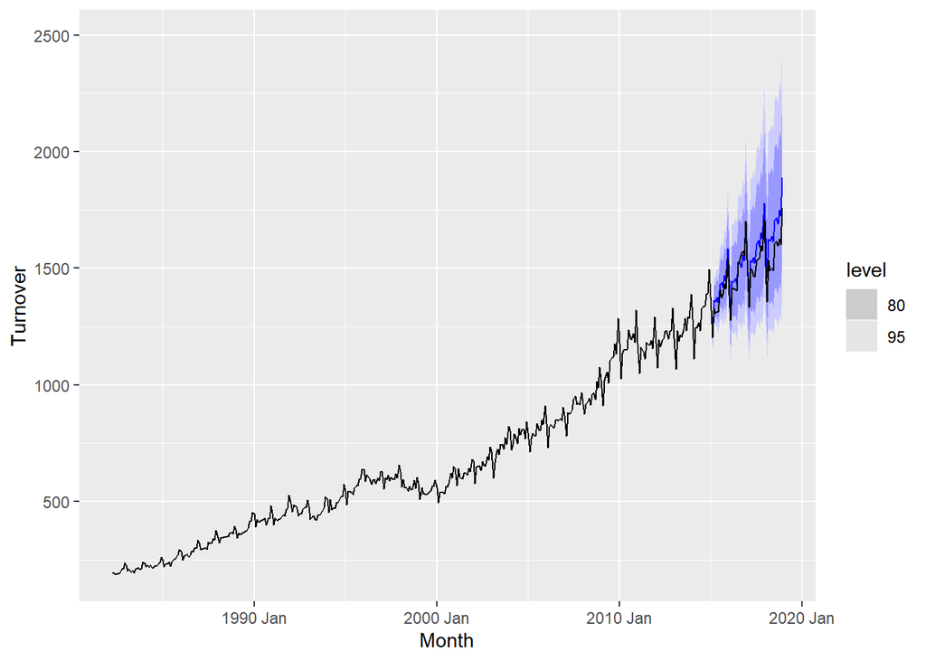

```r
fc %>%
  filter(.model == "decomp_bc") %>%
  autoplot(takeaway)
```

- The test dataset along with the forecasts

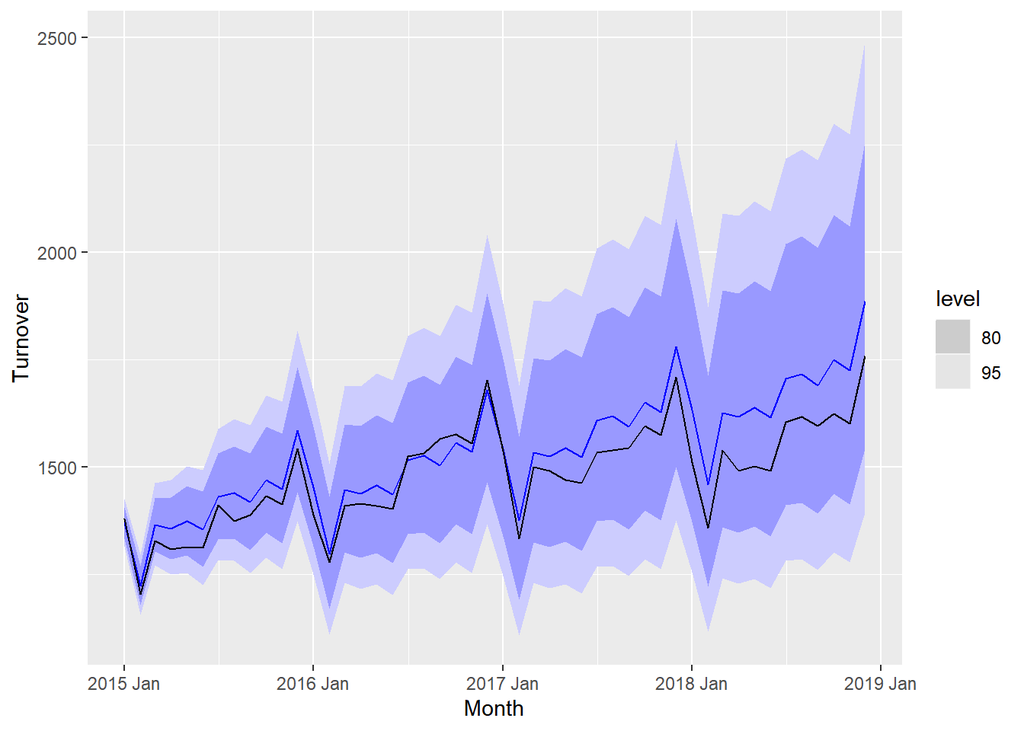

```r
test <- takeaway %>%
  filter(Month > max(Month) - test_years * 12)

fc %>%
  filter(.model == "decomp_bc") %>%
  autoplot(test)
```

- The training dataset and the fitted values

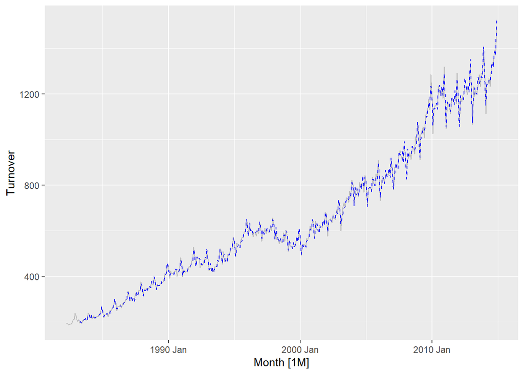

```r
fitted_vals <- fit %>% augment()
fitted_vals %>%
  filter(.model == "decomp_bc") %>%
  autoplot(Turnover, colour = "gray") +
  geom_line(aes(y=.fitted), colour = "blue", linetype = "dashed")
```

In the above graphs the model seems to behave really well and capture the subtleties of the series. However, the residuals exhibit stong autocorrelation (next step). This shows that graphical assessment of the series + forecast might be compelling but insufficient to judge the extent to which a model could be improved.

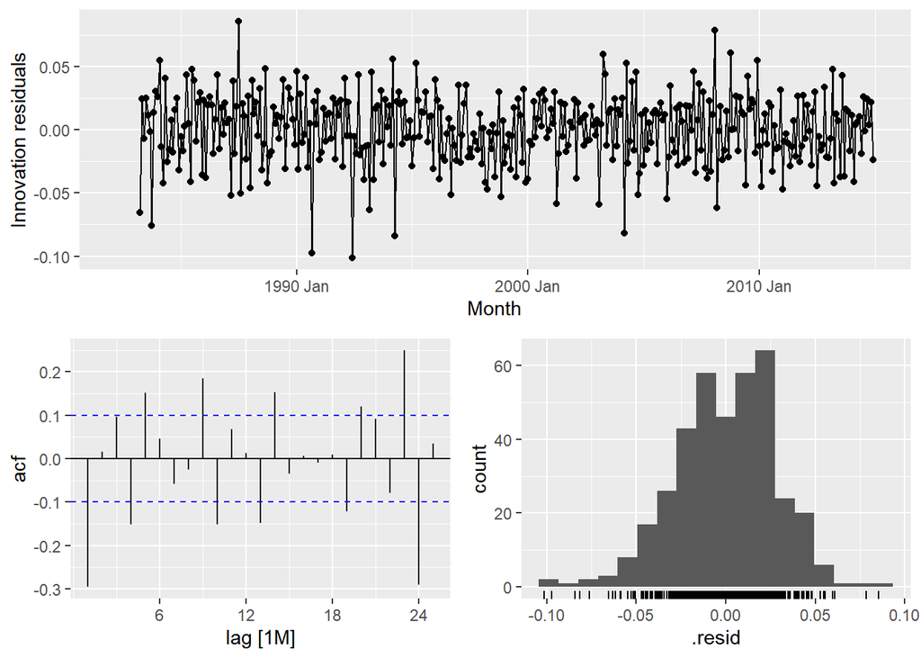

```r
fit %>%
  select(decomp_bc) %>%
  gg_tsresiduals()
```

The residuals exhibit a high degree of correlation. This alone indicates that, despite its apparent relative good behavior, the model can be substantially improved. That is: there is information left in the residuals that the model could have included.

## Exercise 3

`tourism` contains quarterly visitor nights (in thousands) from 1998 to 2017 for 76 regions of Australia.

```r
tourism %>% distinct(Purpose)
```

```
# A tibble: 4 × 1
  Purpose
  <chr>
1 Business
2 Holiday
3 Other
4 Visiting
```

1. Extract data from the Gold Coast region using `filter()` and aggregate total overnight trips (sum over `Purpose`) using `summarise()`. Call this new dataset `gc_tourism`. Create a timeplot of `gc_tourism` as well as a correlogram.

```r
gc_tourism <- tourism %>%
  filter(Region == "Gold Coast") %>%
  summarize(
    Trips = sum(Trips)
  )

gc_tourism
```

```
# A tsibble: 80 x 2 [1Q]
   Quarter Trips
     <qtr> <dbl>
 1 1998 Q1  827.
 2 1998 Q2  681.
 3 1998 Q3  839.
 4 1998 Q4  820.
 5 1999 Q1  987.
 6 1999 Q2  751.
 7 1999 Q3  822.
 8 1999 Q4  914.
 9 2000 Q1  871.
10 2000 Q2  780.
# … with 70 more rows
```

```
Plot variable not specified, automatically selected `.vars = Trips`
```

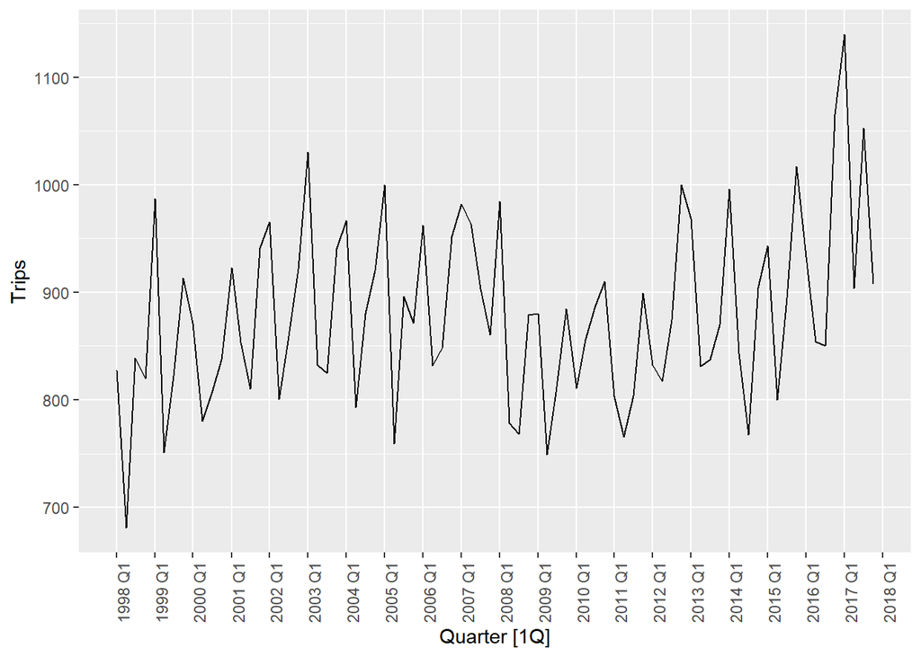

```r
gc_tourism %>% autoplot()  +
               scale_x_yearquarter(date_breaks = "1 year",
                                   # For quarters it is best to manually construct the sequence
                                   minor_breaks = "1 year") +
               theme(axis.text.x = element_text(angle = 90))
```

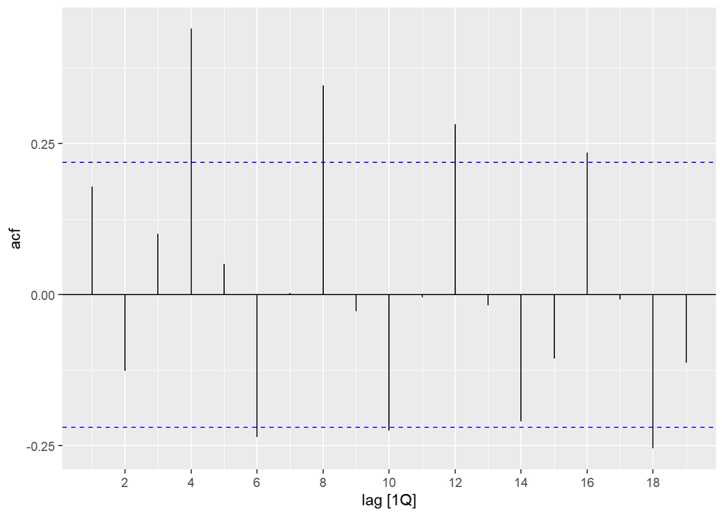

```r
gc_tourism %>% ACF(Trips) %>% autoplot()
```

Examining the timeplot does not reveal any evident seasonality. The series is the combination of 4 subseries and the timeplot pattern does not exhibit a clear regularity.

However the correlogram reveals that this series seems to have a somewhat complex correlogram the one hand it exhibits a yearly seasonal period visible on the spikes at lags 4-8-12….

The negative spikes at 2, 6, 10… are related to midpoints of the seasonal period.

What follows is a more detailed analysis of the seasonality of this series. It is not expected from you at the exam.

**Additional analysis, unexpected for the first part of the subject**

To better understand the timeplot, we may inspect the subseries that we that we added using `summarize()` + `sum()`. If we filter for the region Gold Coast, we will have 4 series, one for each `Purpose` of the trip:

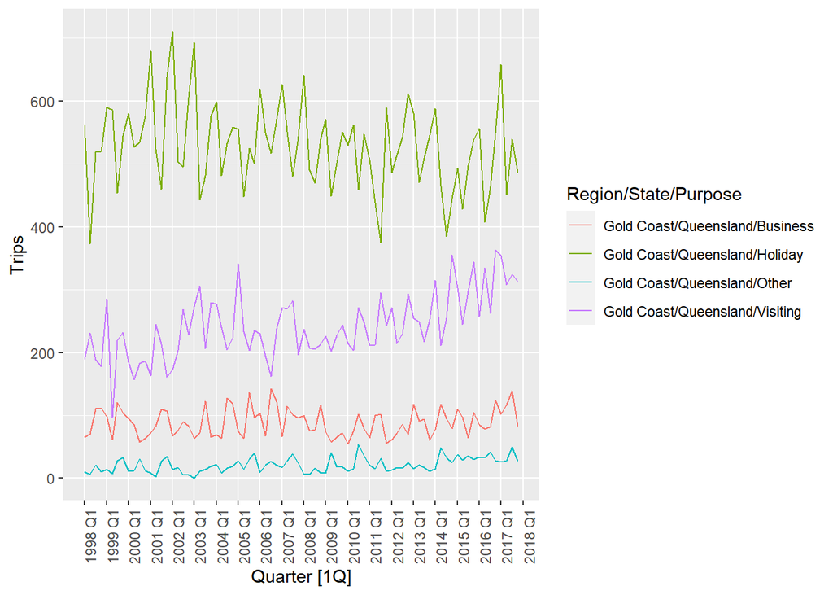

```r
gc_tourism_gc <- tourism %>%
  filter(Region == "Gold Coast")

gc_tourism_gc %>% autoplot(Trips)  +
                  scale_x_yearquarter(date_breaks = "1 year",
                                      # For quarters it is best to manually construct the sequence
                                      minor_breaks = "1 year") +
                  theme(axis.text.x = element_text(angle = 90))
```

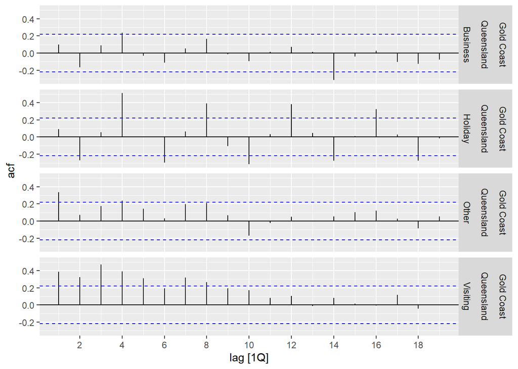

```r
gc_tourism_gc %>% ACF(Trips) %>% autoplot()
```

We see that, of the four time series we have added at the beginning of the exercise, only the subseries for `Purpose == "Holiday"` has a marked seasonality. This can be seen both on the correlogram and on the features table below:

```r
gc_tourism_gc %>%
  features(Trips, feat_stl) %>% select(Region, State, Purpose, trend_strength, seasonal_strength_year)
```

```
# A tibble: 4 × 5
  Region     State      Purpose  trend_strength seasonal_strength_year
  <chr>      <chr>      <chr>             <dbl>                  <dbl>
1 Gold Coast Queensland Business          0.442                  0.399
2 Gold Coast Queensland Holiday           0.540                  0.679
3 Gold Coast Queensland Other             0.629                  0.374
4 Gold Coast Queensland Visiting          0.639                  0.240
```

In the following table, the column `trend_strength` indicates how strong the trend component of the time series is and the column `seasonal_strength_year` indicates how strong the seasonal component is. Both range from 0 to 1, with 1 indicating strongest.

As a result, the addition of the 4 series to form the initial series of the exercise presents seasonality that is detectable in the correlogram while its overall timeplot does not exhibit such a clear seasonal pattern.

**End of the additional analysis**

2. Using `slice()` or `filter()`, create three training sets for this data excluding the last 1, 2 and 3 years.

```r
gc_train_1 <- gc_tourism %>% slice(1:(n() - 4))
gc_train_2 <- gc_tourism %>% slice(1:(n() - 8))
gc_train_3 <- gc_tourism %>% slice(1:(n() - 12))
```

3. Compute **one year** forecasts for each training set using the seasonal naïve method (`SNAIVE()`). Call these `gc_fc_1`, `gc_fc_2` and `gc_fc_3`, respectively. Generate one year forecasts for each model. Create a single timeplot with the time series (train+test sets) and the forecasts produced by the three models

```r
gc_fit <- bind_cols(
  gc_train_1 %>% model(gc_fc_1 = SNAIVE(Trips)),
  gc_train_2 %>% model(gc_fc_2 = SNAIVE(Trips)),
  gc_train_3 %>% model(gc_fc_3 = SNAIVE(Trips))
)

gc_fc <- bind_cols(
  gc_train_1 %>% model(gc_fc_1 = SNAIVE(Trips)),
  gc_train_2 %>% model(gc_fc_2 = SNAIVE(Trips)),
  gc_train_3 %>% model(gc_fc_3 = SNAIVE(Trips))
) %>% forecast(h = "1 year")
```

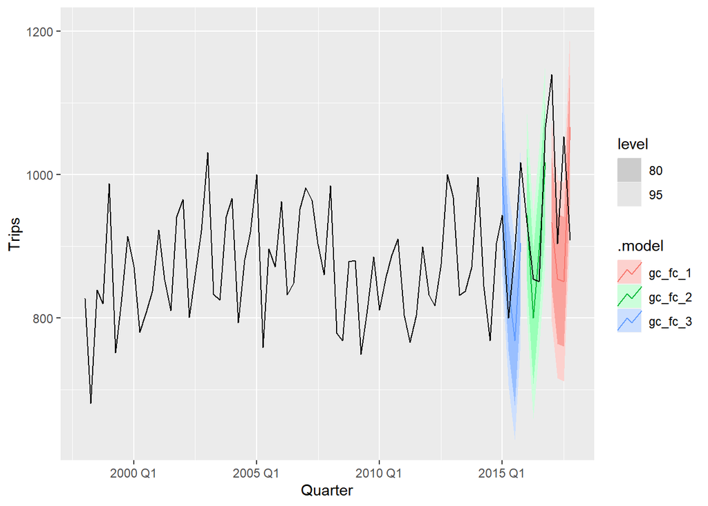

```r
gc_fc %>% autoplot(gc_tourism)
```

4. Use `accuracy()` to compare the test set forecast accuracy(). Compute the accuracy on both the train and test datasets:
- Accuracy metrics based on the training dataset (on the residuals):

```r
gc_fit %>%
  accuracy() %>%
  arrange(MASE) %>%
  select(.model, .type, MAE, RMSE, MAPE, MASE, RMSSE)
```

```
# A tibble: 3 × 7
  .model  .type      MAE  RMSE  MAPE  MASE RMSSE
  <chr>   <chr>    <dbl> <dbl> <dbl> <dbl> <dbl>
1 gc_fc_1 Training  57.9  70.6  6.62     1     1
2 gc_fc_2 Training  59.0  71.9  6.76     1     1
3 gc_fc_3 Training  57.4  70.5  6.61     1     1
```

We see that for all three models, the MASE and RMSSE is 1. That is because the three models are `SNAIVE` models and their performance is being compared against the performance of a seasonal naive model, since the data is seasonal.

We can see that there is virtually no difference in the performance of the three models, that is, the training dataset does not seem to affect much the performance of the seasonal naive model for this particular dataset

- Accuracy metrics based on the test dataset (forecast errors)

```r
gc_fc %>%
  accuracy(gc_tourism) %>%
  arrange(MASE) %>%
  select(.model, .type, MAE, RMSE, MAPE, MASE, RMSSE)
```

```
# A tibble: 3 × 7
  .model  .type   MAE  RMSE  MAPE  MASE RMSSE
  <chr>   <chr> <dbl> <dbl> <dbl> <dbl> <dbl>
1 gc_fc_2 Test   39.5  43.1  4.32 0.670 0.599
2 gc_fc_3 Test   83.9  91.4  9.07 1.46  1.30
3 gc_fc_1 Test  154.  167.  15.1  2.66  2.36
```

We can see that, despite the underlying model being the same, the performance varies significantly depending on the train-test split performed. Model 2 performs significantly better, but this is probably chance.

5. What would you do to assess the performance of the model in a more statitically robust manner?

We see that for this particular dataset, the performance of the model varies significantly depending on the test-train split that we perform. To assess the performance of the models in a more statistically robust manner, Cross-validation would be a more sensible approach.

This would generate a series of train-test datsets against which the model would be assessed. The performance of the model along all those datasets would be averaged, resulting in a much more robust metric of the performance we could expect from the model.